# Data Visualization Tips

## Themes and Labels

Before this semester, I would usually use the `xlab()` and `ylab()` ggplot functions to elucidate the meaning of axes, which isn’t bad, but still leaves much to be desired. Following my professor’s suggestion, I now use ggplot’s `scale_x/y_...()` functions even when just trying to change axes name as typing it in makes me subconsciously think if I should change anything else about the axes, such as tick marks, tick labels, or some type of mathematical transformation. This little trick has done wonders for me, and I now use it every time I make a plot. Furthermore, I previously never bothered using any themes. It’s hard to believe that I was this lazy before, especially when adding `+ theme_minimal()` to the end of your plot code immediately makes it look better.

Let’s apply these ideas to the Bob Ross Paintings data to see the difference it makes.

```r
# Read in data from GitHub repository
paints <- read_csv('https://raw.githubusercontent.com/rfordatascience/tidytuesday/master/data/2023/2023-02-21/bob_ross.csv', show_col_types = F)
```

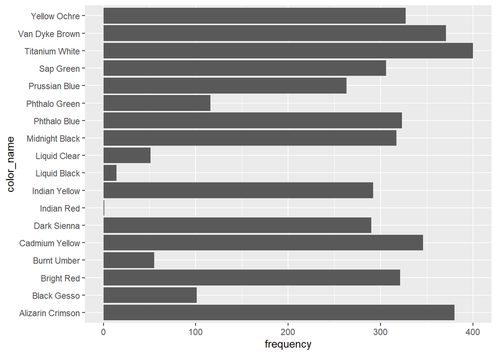

```r
# Plot with ggplots default settings
# *paint_data is the resulting dataframe after the paints dataframe was cleaned,
# see .rmd file for cleaning process
ggplot(paint_data, aes(x = frequency, y = color_name)) +
  geom_col()
```

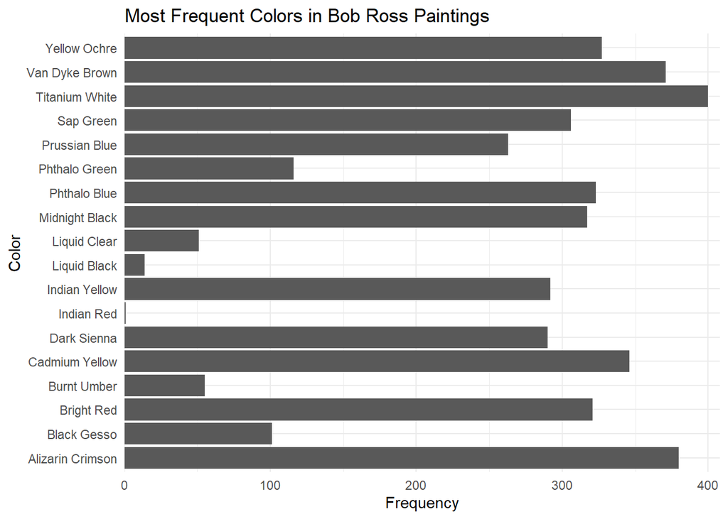

```r
# Plot after adjusting Themes and Labels
ggplot(paint_data, aes(x = frequency, y = color_name)) +
  geom_col() +
  scale_y_discrete(name = "Color") +
  scale_x_continuous(name = "Frequency", expand = expansion(mult = c(0, 0.02))) +
  ggtitle("Most Frequent Colors in Bob Ross Paintings") +
  theme_minimal()
```

That’s a good start, you can already see the difference in quality. But there is still more to be done.

## Ordering

The order of elements on a plot and its legend can affect the overall readability. When your data has discrete categories, such as paint colors in our example, it makes sense to order the elements on the plot by some numerical quantity. You can use counts, frequencies, or simply raw numerical values that correspond to the categories, and in this case we will use the frequency of paint usage.

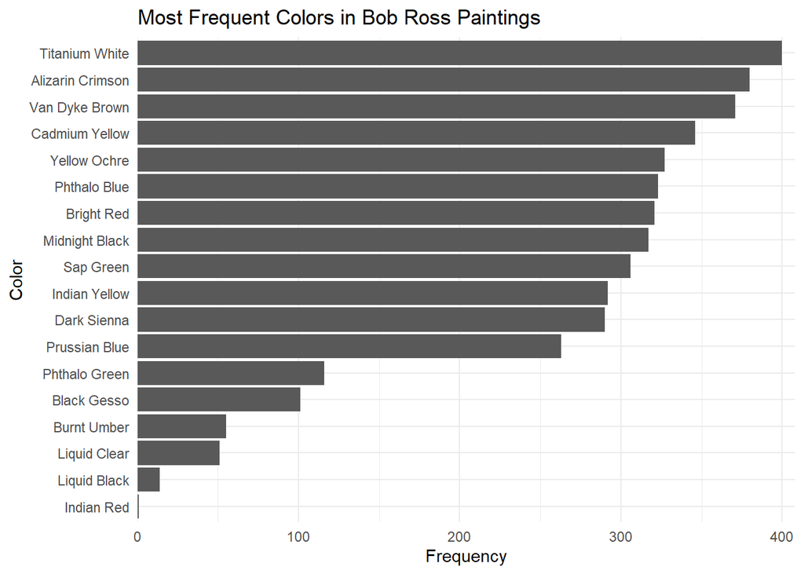

```r
# Use mutate and fct_reorder functions to reorder elements in dataframe
paint_data %>% mutate(color_name = fct_reorder(color_name, frequency)) %>%
  ggplot(aes(x = frequency, y = color_name)) +
  geom_col() +
  scale_y_discrete(name = "Color") +
  scale_x_continuous(name = "Frequency", expand = expansion(mult = c(0, 0.02))) +
  ggtitle("Most Frequent Colors in Bob Ross Paintings") +
  theme_minimal()
```

Look at the huge difference that ordering makes, now you can easily tell the most and least common paints used.

Now let’s use an example to address the ordering of a plot legend. In my [Data Visualizations for the 2023 NBA Season](https://rosswoleben.com/projects/2023-nba) post, I had a plot showing the all-time leading scorers in the NBA. In this plot, I put LeBron James on the top of the legend, as he has the most overall points. This order is much more inuitive than having the legend by ordered alphabetically, which is the ggplot default.

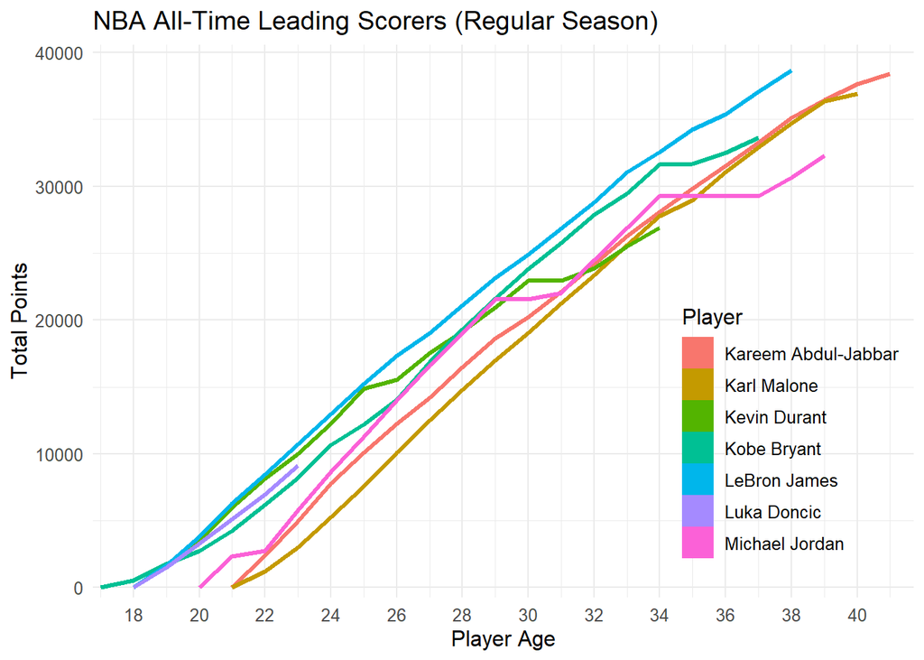

```r
# Read in NBA scoring data
nba_data <- read_csv('https://raw.githubusercontent.com/ross-wgh/MSDS_Notes/main/May2023/Data_Visualization_and_Exploration/nba_scoring_leaders.csv', show_col_types = F)

# Make function as the plotting code will be the exact same - only the input (data) will be changed
nba_plot <- function(data){
  ggplot(data, aes(x = Age, y = CumePoints, color = Player)) +
  geom_line(linewidth = 1.1, key_glyph = 'rect') +
  scale_x_continuous(
    breaks = seq(from = 18, to = 42, by = 2),
    expand = expansion(mult = c(0.01, .03)),
    name = "Player Age"
  ) +
  scale_y_continuous(name = 'Total Points', expand = expansion(mult = c(0.02, .05))) +
  ggtitle("NBA All-Time Leading Scorers (Regular Season)") + theme_minimal() +
  theme(text = element_text(size = 12),
        legend.position = c(.85, .3))
}

# Plot without changing the order (ggplot defaults to ordering players alphabetically)
nba_plot(nba_data)
```

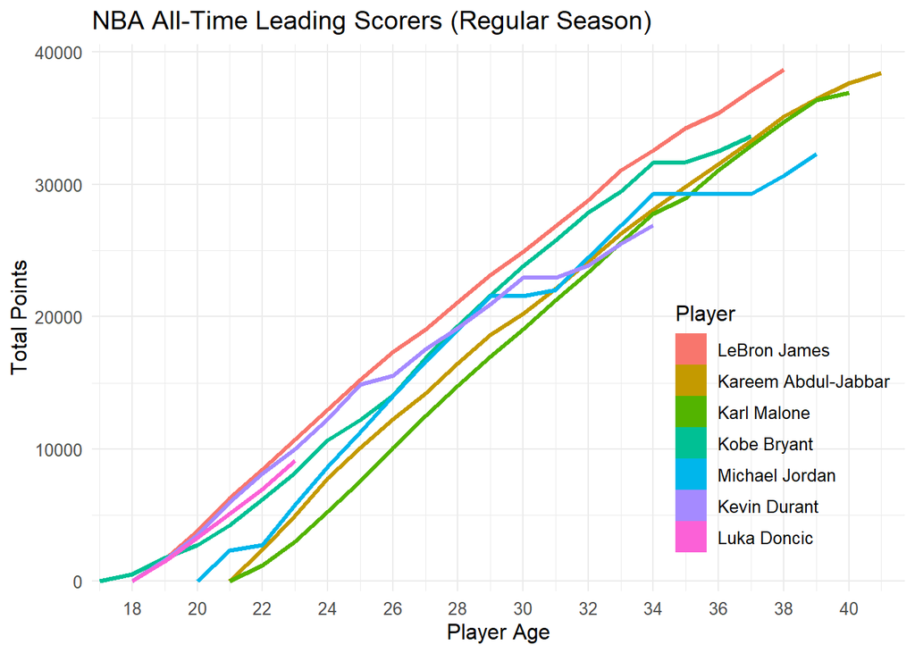

```r
# Use mutate to reorder the players
nba_data_ordered <- nba_data %>% mutate(Player = fct_relevel(Player, "LeBron James", "Kareem Abdul-Jabbar", "Karl Malone", "Kobe Bryant", "Michael Jordan", "Kevin Durant", "Luka Doncic"))

# Plot with the legend ordered by the top scorers
nba_plot(nba_data_ordered)
```

This may seem like a subtle change, but now you can clearly see the rankings of the top scorers, as well their scoring over time. You may notice that the colors are slightly different than what you see in the final plot on my website, so let’s address that now.

## Color

Picking the right set of colors can make a huge difference in the reception of a plot. You may have noticed that the Bob Ross paintings plot we’ve been working with still feels incomplete: it should have color! It can be a laborious challenge to come up with a good color scheme for your plot, but luckily the data we’re working with gives us an intuitive set of colors to work with - the paint colors in the data set.

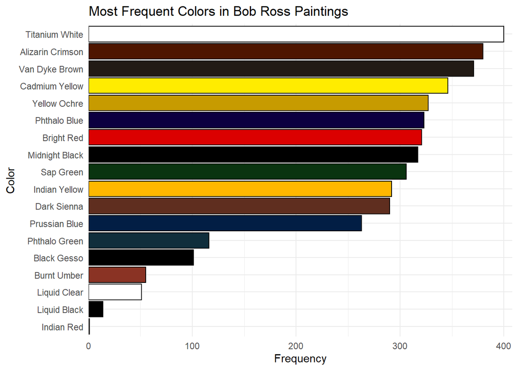

```r
# Putting our ideas of Themes and Labels, Ordering, and Color together...
paint_data %>% mutate(color_name = fct_reorder(color_name, frequency)) %>%
  ggplot(aes(x = frequency, y = color_name, fill = hex_value)) + # Use fill aesthetic to map colors onto the bars of plot
  geom_col(color = 'black', fill = paint_data$hex_value) +
  scale_y_discrete(name = "Color") +
  scale_x_continuous(name = "Frequency", expand = expansion(mult = c(0, 0.02))) +
  ggtitle("Most Frequent Colors in Bob Ross Paintings") +
  theme_minimal()
```

Now this is a publication-quality plot! It has clear labels, an order that makes for easy comparisons, and a visually appealing and informative color scheme.

When working with data that does not have an implied set of colors to use, you may need to employ some color theory. Although there are several different color spaces that have their own strengths and weaknesses, the Hue-Chroma-Luminance (HCL) color space is a pretty solid option. This color space devises a system that takes some of the guesswork out of selecting a palette. Conveniently, the colorspace package in R provides some universally applicable color palettes as well as an R Shiny application (`colorspace::choose_color()`) that can be used to create a complementary color palette. Let’s look at two examples of color palettes that I quickly made with this app.

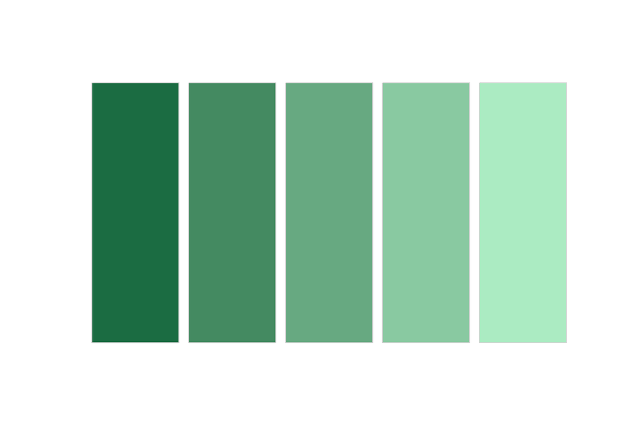

```r
# Color palette that works well if you want to use a gradient of greens
greens <- c("#1B6C42", "#448A61", "#67A981", "#89C9A1", "#ABEBC2")
swatchplot(greens)
```

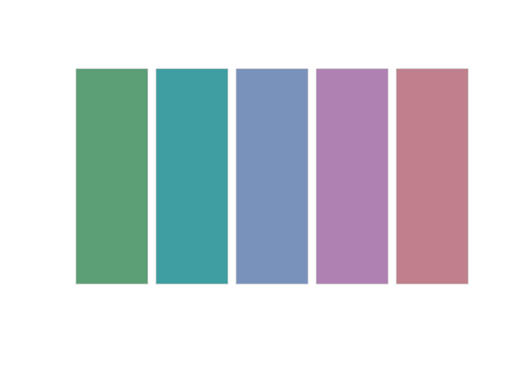

```r
# Color palette with colors that all have the same luminance values - provides a nice pastel look
colors <- c("#5C9E76", "#3E9EA1", "#7992BB", "#AF81B3", "#BF7F8D")
swatchplot(colors)
```

As I mentioned, its important to consider what data your custom color palettes are being used for. If your data is continuous, then a subtle transition between those shades of green may be a good option. If your data is discrete, the second color palette with several different hues may be a good option. There are several color palettes within the tidyverse that fill specific niches, but understanding what colors work with each other unlocks another level of creative potential when creating your visualizations.

## Useful Packages

There were 3 really cool packages that I learned this semester. I already gave a brief summary of them in the main website post, so I’ll just run a quick demo of each here:

#### patchwork

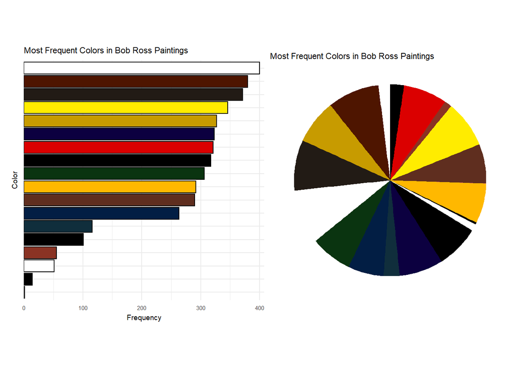

```r
# First store the subplots into variables so they are easier to manipulate
bar_plot <-
  paint_data %>% mutate(color_name = fct_reorder(color_name, frequency)) %>%
    ggplot(aes(x = frequency, y = color_name, fill = hex_value)) +
    geom_col(color = 'black', fill = paint_data$hex_value) +
    scale_y_discrete(name = "Color", labels = NULL) +
    scale_x_continuous(name = "Frequency", expand = expansion(mult = c(0, 0.02))) +
    ggtitle("Most Frequent Colors in Bob Ross Paintings") +
    theme_minimal() +
    theme(text = element_text(size = 7))

pie_plot <-
  paint_data %>% mutate(color_name = fct_reorder(color_name, frequency)) %>%
    ggplot(aes(x = frequency, '', fill = hex_value)) +
    geom_col(fill = paint_data$hex_value) +
    scale_y_discrete(name = "Color") +
    scale_x_continuous(name = "Frequency", expand = expansion(mult = c(0, 0.02))) +
    ggtitle("Most Frequent Colors in Bob Ross Paintings") +
    coord_polar() +
    theme_void() +
    theme(text = element_text(size = 7))

# Use basic operators (+, /, |) to create compound figure
bar_plot | pie_plot
```

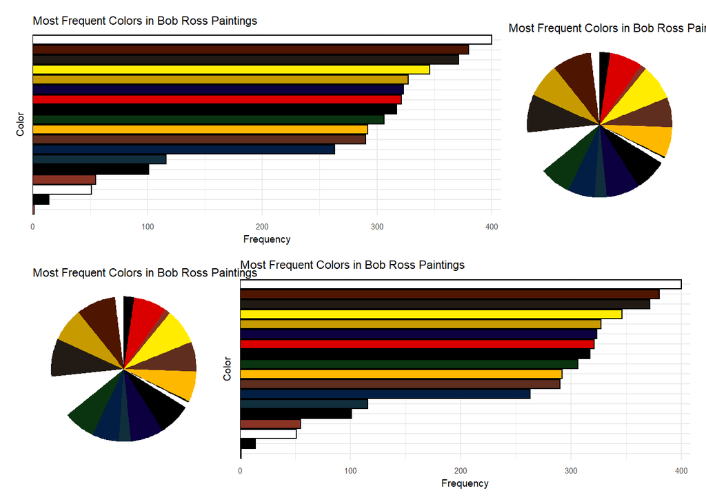

```r
# Here there is a slight issue with the titles overlapping that can be fixed with some slightly more complex
# code, but for a quick demo, it gives a pretty good impression of what patchwork can do.
(bar_plot | pie_plot) / (pie_plot + bar_plot)
```

#### ggiraph

```r
# Before creating the interactive plot, we need to add a label for each bar
paint_data$label <- paste(paint_data$color_name, ": ", paint_data$frequency)

bob_ross_interactive <-
  paint_data %>% mutate(color_name = fct_reorder(color_name, frequency)) %>%
  ggplot(aes(x = frequency, y = color_name, fill = hex_value)) +
  # use geom_col_interactive instead of geom_col to create interactive element with ggiraph
  geom_col_interactive(aes(data_id= color_name, tooltip = label), color = 'black', fill = paint_data$hex_value) +
  scale_y_discrete(name = "Color") +
  scale_x_continuous(name = "Frequency", expand = expansion(mult = c(0, 0.02))) +
  ggtitle("Most Frequent Colors in Bob Ross Paintings") +
  theme_minimal()

# use girafe function to render the plot
girafe(
  ggobj = bob_ross_interactive,
  options = list(
    # These options customize the javascript and css for the plot
    opts_hover(css = "fill-opacity: 0.01;"),
    opts_hover_inv(css = "opacity: 0.3;")
  )
)
```

[interactive chart not shown]

#### sf

```r
# Doesn't make sense to make a full demo here, as I'll shortly touch upon geospatial data, so just take note
# of the multi-polygon objects in the geometry column of this sf-dataframe

# get_acs() is a function from the tidycensus package that makes it incredibly easy to get geometries for US land area
united_states <-
  get_acs(
    geography = "county",
    # This variables argument corresponds to per capita income, but it doesn't really matter for our use;
    variables = "B19013_001",
    year = 2020,
    # We are mainly interested in grabbing the geometries of the US for drought data
    geometry = TRUE
  )
```

```r
united_states
```

```
## Simple feature collection with 3221 features and 5 fields
## Geometry type: MULTIPOLYGON
## Dimension:     XY
## Bounding box:  xmin: -179.1489 ymin: 17.88328 xmax: 179.7785 ymax: 71.36516
## Geodetic CRS:  NAD83
## First 10 features:
##    GEOID                           NAME   variable estimate  moe
## 1  01053       Escambia County, Alabama B19013_001    35558 2902
## 2  01129     Washington County, Alabama B19013_001    42331 4919
## 3  01113        Russell County, Alabama B19013_001    42208 2255
## 4  01107        Pickens County, Alabama B19013_001    40362 2740
## 5  01119         Sumter County, Alabama B19013_001    26150 2033
## 6  04027           Yuma County, Arizona B19013_001    48790 1981
## 7  04001         Apache County, Arizona B19013_001    33967 2108
## 8  04017         Navajo County, Arizona B19013_001    43140 2357
## 9  05131     Sebastian County, Arkansas B19013_001    47878 2067
## 10 06037 Los Angeles County, California B19013_001    71358  336
##                          geometry
## 1  MULTIPOLYGON (((-87.61558 3...
## 2  MULTIPOLYGON (((-88.46443 3...
## 3  MULTIPOLYGON (((-85.43472 3...
## 4  MULTIPOLYGON (((-88.34043 3...
## 5  MULTIPOLYGON (((-88.42082 3...
## 6  MULTIPOLYGON (((-114.8163 3...
## 7  MULTIPOLYGON (((-110.0007 3...
## 8  MULTIPOLYGON (((-110.7507 3...
## 9  MULTIPOLYGON (((-94.4476 34...
## 10 MULTIPOLYGON (((-118.6044 3...
```

## Geospatial Data

In the course, we primarily focused on choropleth maps, which use colors to represent an aggregated measurement across a geographic area. There are plenty of resources online to find some interesting data (US Census data gives a ton of information), but you may need to do some manipulating to get it in a sf-compatible format. Here is an example using drought data for all counties in the contiguous states.

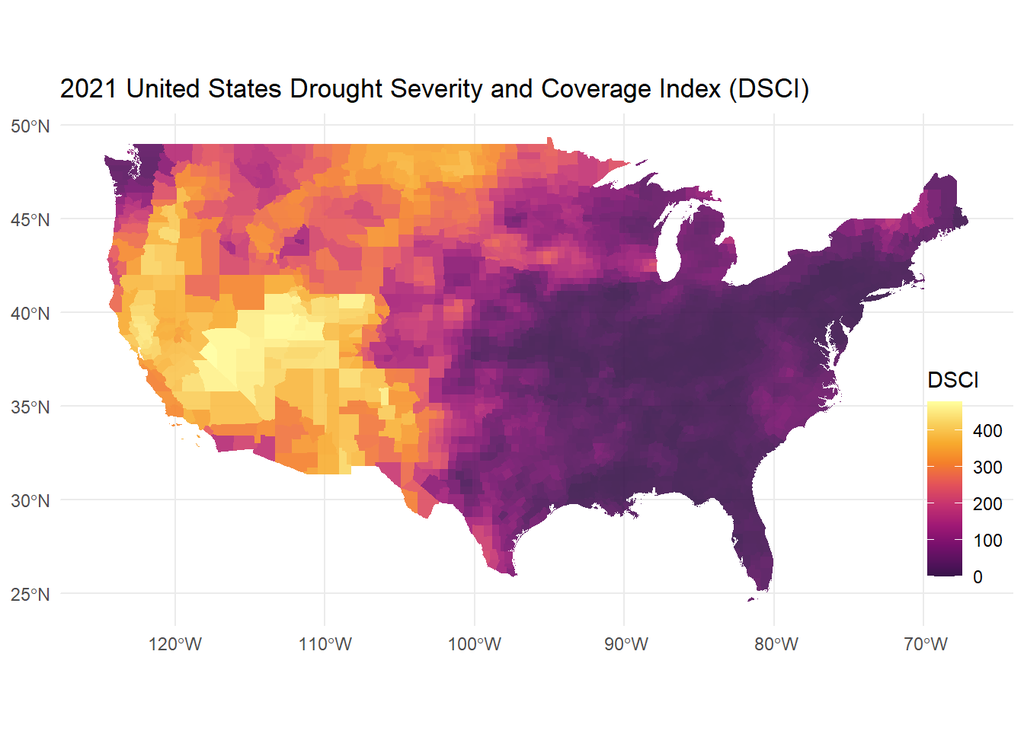

```r
# This example was inspired by Julia Silge's post at https://juliasilge.com/blog/drought-in-tx/
# Read in data from GitHub repository
drought_raw <- read_csv('https://raw.githubusercontent.com/rfordatascience/tidytuesday/master/data/2022/2022-06-14/drought-fips.csv')

# Only select observations from the year 2021
drought_us <- drought_raw %>%
  filter(lubridate::year(date) == 2021) %>%
  group_by(GEOID = FIPS) %>%
  summarise(DSCI = mean(DSCI)) %>%
  ungroup()


drought_united_states <- united_states %>%
  # Ignore drought data for Puerto Rico, Hawaii, and Alaska for a more compact map
  filter(GEOID < '72000' &
         (GEOID < '02000' | GEOID > '03000') &
         (GEOID < '15000' | GEOID > '16000')) %>%
  # Join US Geometry to drought data
  left_join(drought_us)

drought_united_states %>%
  ggplot(aes(fill = DSCI)) +
  # Use geom_sf to display simple features geometry into a ggplot
  geom_sf(alpha = 0.9, color = NA) +
  scale_fill_continuous_sequential(palette = "Inferno", begin = 0.15, rev = FALSE) +
  # ^ Use color scheme that makes sense for droughts
  ggtitle("2021 United States Drought Severity and Coverage Index (DSCI)") +
  theme_minimal() +
  theme(legend.position = c(.95, .3))
```

## Resources:

The creator of ggplot, Hadley Wickham, has an excellent resource that discusses both basic and complex programming concepts in R. It is available at https://adv-r.hadley.nz/introduction.html

The professor of my “Data Visualization and Exploration” course, Claus Wilke, has published an e-book that provides an overview of the topics discussed in the class. I highly recommend it for those even remotely interested in data, as it offers a code-free approach to discussing general considerations of data visualization visualization.* It is available at https://clauswilke.com/dataviz/

ggplot2 has an excellent documentation/stylistic guide for plotting https://ggplot2-book.org/

See my article at https://www.rosswoleben.com/projects/data-vis for further discussion.